# PROJECT - IE 582 / GROUP 3

*by Gizem Güneş, Emre Emil, Mert Çetinkaya (Report)*

*3 January 2020*

# A. Introduction

Sports betting is a big sector that attracts lots of people from all around the world. Every week, millions of people gamble on sport bets and they try to earn money on these bets. While betting, people look at odds and type of bets (like predicting the result of a football match, predicting total number of goals in a football match etc.) and choose the most seductive ones and their bookmakers and gamble on that. Odd bookmakers, somehow, try to attract people by their odds while trying to maximize their profit.

Since number of people betting is increasing day by day, academic world also interests in this field. There are lots of academic research related to betting with different concepts. While some research interest in building a good model which predicts to outcome of matches, some of them focus on feature engineering, and some of them try to maximize profit of bookmakers whatever the outcome of a match. As a result, gambling problems are interesting for academic world, and the field is significant research area due to popularity of betting.

In this project, we have tried to make predictions for the results of several English Premier League matches using old matches data and related odd values. Our match data starts from the matches of 2017 and using our data in our hand we try to produce predictive models to guess the probabilities of each outcome of matches that belong to rounds between 14 and 21 of English Premier League in 2019-2020 season. We use data mining methods to get a good prediction of outcomes. When the models are compared with each other, RPS and accuracy values are evaluated.

In this report, past research studies related to this subject is expressed in the next section. Approach section includes what kind of information data includes and how we approach this problem. Results section includes RPS and accuracy outcomes of the models and lastly, conclusion and future work is also mentioned in the last part.

# B. Related Literature

Karlis and Ntzoufras (1998) research on finding a statistical model which can predict the outcomes of soccer games in a classical way. They use Greek League data for season 1997-1998. The features which they use are classified into three classes, namely offensive parameters, defensive parameters and home effect. After comparing different statistical models, they find that Poisson distribution suffices for describing games.

Suzuki et al. (2006) propose a Bayesian methodology for predicting match outcomes. The methodology is illustrated on the 2006 Soccer World Cup. The features they use in the research are classified into two groups, namely specialists’ opinions and the FIFA ratings. The method is applied to calculate the outcome probabilities at each match and also to simulate the whole competition in order to estimate classification probabilities in group stage and winning tournament chances for each team. Method is evaluated according to the DeFinetti measure and the percentage of correct forecasts.

Graham and Stott (2008) evaluate rationality of bookmaker (William Hill) odds with comparing the odds and ordered probit model, which they build to generate predictions for English football matches. Features which they use are team ratings, home advantage, distance travelled, bookmaker's odds. They show that there are systematic biases in bookmaker odds, and that these biases cannot be explained by William Hill odds omitting valuable, or excluding extraneous, information.

Langseth (2013) tries to find a statistical model which, based on the game-history so far in a season, can predict the outcome of next round's matches. After predicting, s/he considers the use of different money management techniques to evaluate and compare three models they use, namely static, dynamic and data-intensive. In addition, s/he also compares three different betting strategies. Therefore, s/he tries to maximize profit of bookmaker whatever the outcome.

Shi et al. (2013) explore whether models used are more significant than features using to build model or not. They evaluate factors of team success and adjusted efficiencies as features. They compare the models and features by looking performance of models. As a result, they show that choosing the right features gives the best results, so feature selection is more significant.

Louzada et al. (2014) try to estimate the average goals scored by each team by assuming that the number of goals scored by a team in a match follows a univariate Poisson distribution. They consider linear models which, with good predictive quality, easy implementation and low computational effort, express the sum and the difference of goals scored. The features they use are the goal average in a match, the home-team advantage, the team's offensive power, the opponent team's defensive power and a crisis indicator. The methodology is applied to the 2008-2009 English Premier League.

Bunker and Thabtah (2019) provide a critical analysis of the literature in ML, focusing on the application of Artificial Neural Network (ANN) to sport results prediction. They propose a novel sport prediction framework through which ML can be used as a learning strategy. Some features they use in the research are results of historical matches, player performance indicators and opposition information.

# C. Approach

In this project, we have five data sets, namely bets, booking, goals, matches and statistics. Bets data includes bookmaker with odd type, odd value and odd epoch for a match. Booking data includes fault, card and time information of home and away teams for each match. Goals data includes scorer and time information of each goal information for each match. Matches data includes match status, away and home teams, extra time, score, and league id information for each match. Statistics data includes match detailed statistics such as ball possession, corners, fouls, offsides, shots, cards for each matches' home and away team. As a result, data pre-processing is significant for this project since there are lots of different data sets.

While modelling, we use the following values as our input at the beginning:

- no of hometeam win in recent matches (hometeam of the match which is predicted)
- no of hometeam tie in recent matches (hometeam of the match which is predicted)
- no of hometeam loss in recent matches (hometeam of the match which is predicted)
- no of awayteam win in recent matches (awayteam of the match which is predicted)
- no of awayteam tie in recent matches (awayteam of the match which is predicted)
- no of awayteam loss in recent matches (awayteam of the match which is predicted)
- no of hometeam win in recent matches between each other (For hometeam of the match which is predicted)
- no of hometeam tie in recent matches between each other (For hometeam of the match which is predicted)
- no of hometeam loss in recent matches between each other (For hometeam of the match which is predicted)
- probability value for winning of hometeam predicted by bookmakers (hometeam of the match which is predicted)
- probability value for tie predicted by bookmakers (of the match which is predicted)
- probability value for winning of awayteam predicted by bookmakers (awayteam of the match which is predicted)

In step 2, we have added features, which are shown below, to input data set. Since we have seen an improvement in performance metrics of the test and training data sets for models, we decided to also add these features.

- no of hometeam goals in recent matches (hometeam of the match which is predicted)
- no of goals against hometeam in recent matches (hometeam of the match which is predicted)
- no of awayteam goals in recent matches (awayteam of the match which is predicted)
- no of goals against awayteam in recent matches (awayteam of the match which is predicted)
- no of hometeam wins in the league during this season (hometeam of the match which is predicted)
- no of hometeam tie in the league during this season (hometeam of the match which is predicted)
- no of hometeam loss in the league during this season (hometeam of the match which is predicted)
- no of awayteam wins in the league during this season (awayteam of the match which is predicted)
- no of awayteam tie in the league during this season (awayteam of the match which is predicted)
- no of awayteam loss in the league during this season (awayteam of the match which is predicted)
- no of red cards shown to hometeam in last match (hometeam of the match which is predicted)
- no of red cards shown to awayteam in last match (awayteam of the match which is predicted)

After adding red card information, we have seen that there isn't so improvement in the performance metrics of models. Since adding new features to input data set may pose overfitting, and also curse of dimensionality might lead to too complex models and even harder interpretibility of the models, we have decided that this input data set is used in the next steps.

In the following image, you can see the first rows and columns of our input dataset used in the models. The actual dataset exists in our codes as well.

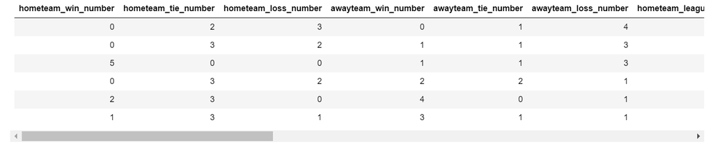

The aim of this project is to get probabilities of each outcome of the upcoming matches in English Premier League. Therefore, our prediction models use input data set, which is indicated above, and give probability values for three possible outcomes of a soccer match. While building our prediction models, we have tried some of the learning algorithms covered during the semester regarding the nature of our problem. We have used multinomial logistic regression, multinomial lasso regression, stochastic gradient boosted trees, random forest and support vector machines methods in this project. Also, we have considered performances of each method with their RPS and accuracy values.

To predict the upcoming matches, each time we read the most recent input data set, also we update the corresponding IDs for predicted matches. Data is split as training and test. Models are trained on training data and used for prediction using the test data. The best model according to RPS values is selected. After that, the best model is used to predict the actual upcoming matches.

To improve the model, we have used cross-validation for finding the best parameter which gives the best result. Also, we provided the bookmaker elimination with an initialization parameter by evaluating the bookmakers' performances according to RPS values. If it is activated, we calculate mean of probabilities which are computed from the best 20 bookmakers' odds. Otherwise, if the initialization parameter of bookmaker elimination is deactivated, we calculate mean of probabilities which are computed from all bookmakers' odds.

Coding is done on R programming language.

# D. Results

The below image (rps-accuracy image) shows us the results of bookmakers and our different models for our training and test data with regards to RPS and accuracy metrics for the outcome of the matches. The same image also exists towards the end of our code as an output and it is the output for the last data that we downloaded while preparing our project.

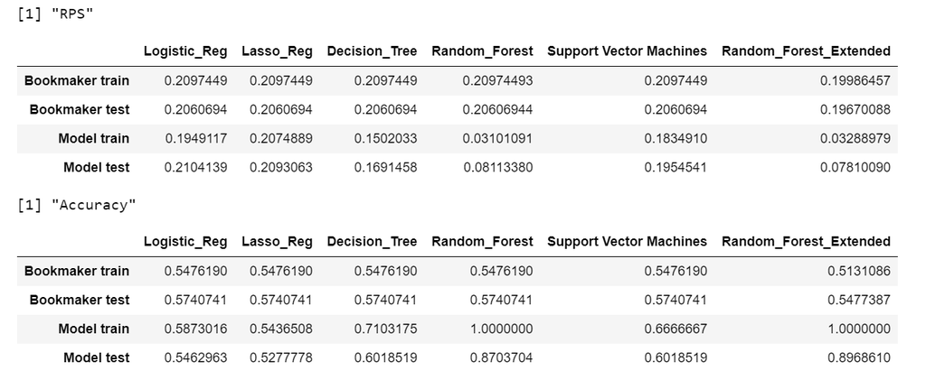

After seeing that Random Forest has the best performance, we tried to improve the model in terms of robustness (if there are no odds given by bookmakers), to eliminate cases of too small tie probabilities and having a better RPS value. As a result, Random Forest Extended version as a new model which is constructed with the data including NA odd values, was introduced and this led to improvement in robustness and eliminating too small tie probabilities. In addition, we see that our two random forest models outperform the other models and predictions of bookmakers. We also see that we get generally better results using our models than the predictions of bookmakers.

To improve Random Forest Extended, we implement cross validation for the parameters seen in the below image. As a result, we saw that implementing cross validation did not contribute a lot. Therefore, we decided not to use cross validation for parameter tuning. We saw that our parameters which are firstly defined work well.

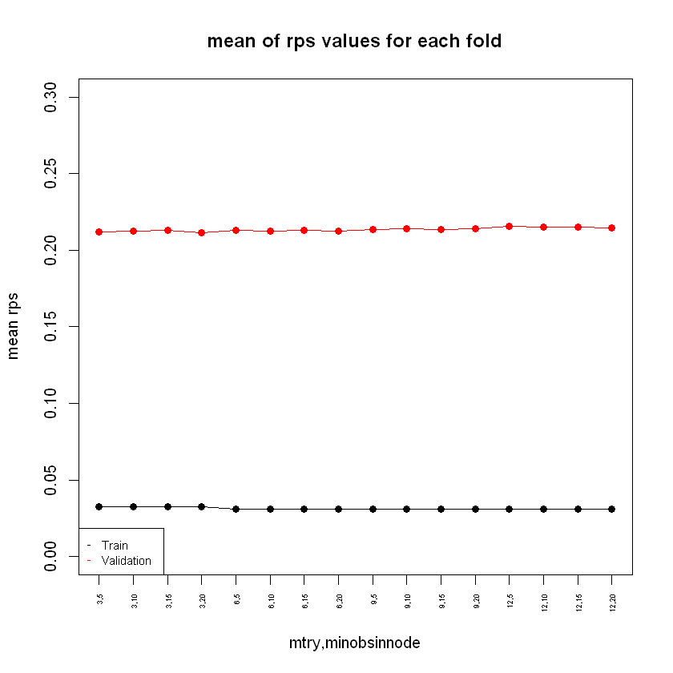

In addition, while splitting the data as training and test data sets, we used random sampling and stratification methods. We saw that the models which are built with the training data, splitting with random sampling have better performance according to RPS and accuracy values. Therefore, we decided that random sampling is used in the next steps instead of stratification. Moreover, after bookmaker elimination is activated, we saw that there is a little improvement in the performances of the models.

When we look at the random forest outcomes for predicting matches, we saw that while random forest has too small tie probabilities due to class imbalance in given data (ties are seen significantly less than other outcomes) and it has sometimes better performance than random forest extended, random forest extended has higher tie probabilities, but sometimes having slightly low performance related to RPS and accuracy metrics compared to Random Forest. Therefore, it seems that calculating mean of outputs of these two methods is logical for us, since in several rounds, average of Random Forest and Random Forest Extended have the best predictions in general.

Lastly, the training and test data used in Random Forest Extended is slightly different than the others because of the approach brought in that model and, consequently, the results for bookmakers are slightly different than they are in the other models as it can be seen in rps-accuracy image above. This is explained in a more detailed way in the comment lines in the related section of our codes.

Below, you can see the predictions that belong to the last prediction round prior to submission date (21st round) for our selected model (average for random forest and random forest extended). These probabilities are also our submitted probabilities for this round.

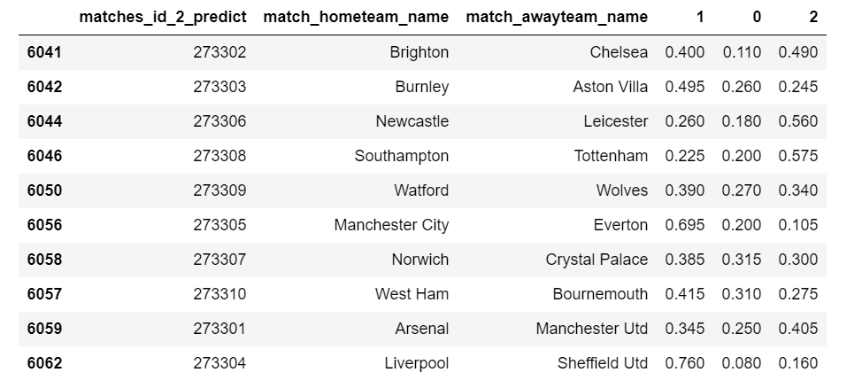

# E. Conclusions and Future Work

### Dataset and Methods Used

In this project, we have tried to predict probability values for winning of hometeam, for winning of awayteam and for tie results and to minimize our RPS (Ranked Probability Score) value.

Dataset: https://drive.google.com/drive/folders/1SkhJNE3ckir74oPMXTP7T3hUD5ZdB501 is used.

Tried models are:

- Multinomial logistic regression
- Multinomial lasso regression
- Stochastic gradient boosted trees
- Random forest
- Average of random forest and random forest extended
- Support vector machines methods

### Interpreting the Methodology and Results

#### Some Methods

Multinomial logistic regression tends to find linear boundaries of classes, therefore when there is a non linearity, it might have lower performance.

The same is valid for Lasso Regression. Even with elimination of irrelevant features we overcome some of the curse of dimentionality but the classification is stuck at a limit.

On the other hand, SVM also tries to seperate the classes. However, with data at hand which can be considered as limited (because of number of matches and data at hand are limited) and which has multi-class responses, this approach also might not grasp the underlying classifier in detail.

Stochastic gradient boosting trees have low RPS when large number of trees and more depth is used. However as the depth increases, RPS values become close to RPS of RF. However the performance of the algorithm decreases, also we face overfitting. RF is better in terms of performance and RPS. Therefore, stochastic gradient boosting trees method is not selected.

#### What is the advantage of RF?

In our feature set, none explains most of the variance. Therefore some features might also present some noise. In general, logistic regression performs better when the number of noise variables is less than or equal to the number of explanatory variables and random forest has a higher true and false positive rate as the number of explanatory variables increases in a dataset. Logistic regression and random forest are comparable for smaller datasets with less than 1000 observations.[8] Therefore, RF or tree based approaches have advantage over logistic regression.

#### Why does RF and Average of RF and RF Extended has best overall predictions?

Random forest has best fit in overall models also when combined with extended random forest, it has the best results. For most of the predictions in several rounds, Average of RF and RF extended have the best predictions. On the contrary, in some rounds random forest predicts a little bit better than the average.

#### Why do we use Average of RF and RF Extended, instead of RF?

In the case of RF, tie probabilities are especially small when away team is stronger than the home team, and there are none or very few ties in previous games. However, because of the ordinality nature of the classes, if hometeam win and away team win probabilities are both high, and tie probability should not be too small. Because for away team or hometeam to make a comeback, they have to be in tie state in between. However, RF considers the classes as nominal. This makes interpretability of RF hard. On the other hand RPS values of RF are very low. So this can be considered as overfitting.

In particular, trees that are grown very deep tend to learn highly irregular patterns: they overfit their training sets, i.e. have low bias, but very high variance. Random forests are a way of averaging multiple deep decision trees, trained on different parts of the same training set, with the goal of reducing the variance. [9]

When RF extended is used, RPS values are closer to RF, and the predictions are more interpretable because of tie probabilities. So to eliminate very low tie percentages, average of the RF and RF extended is used. This has best RPS values and high interpretability.

Tree based approaches have lower RPS than other methods in general.

### Future Work

To grasp the ordinality relationship of outcomes, Markov Chain Based Methods can be tried. The topics are not covered throughout the course.

Different datasets can be used to have more and relevant features. The features can therefore include the effect of Performance of teams & ELO.

In the methods used, correlation of features can be calculated and relevant features can be selected by using feature elimination methods.

K Nearest neighbor methods can also be used in classification, especially in order to detect non-linear boundaries.

# F. References

```
[1] D. Karlis, I. Ntzoufras. 1998. Statistical modelling for soccer games : the Greek league. Athens University of Economics and Business, Greece.
[2] A.K. Suzuki, L.E.B. Salasar, J.G. Leite, F. Louzada-Neto. 2006. A Bayesian approach for predicting match outcomes: The 2006 (Association) Football World Cup. Journal of the Operational Research Society 61:10 1530-1539.
[3] I. Graham, H. Stott. 2008. Predicting bookmaker odds and efficiency for UK football. Applied Economics 40:1 99-109.
[4] H. Langseth. 2013. Beating the bookie: A look at statistical models for prediction of football matches. Norwegian University of Science and Technology, Norway.
[5] Z. Shi, S. Moorthy, A. Zimmermann. 2013. Predicting NCAAB match outcomes using ML techniques – some results and lessons learned. KU Leuven, Belgium.
[6] F. Louzada, A. K. Suzuki, L.E.B. Salasar. 2014. Predicting Match Outcomes in the English Premier League: Which Will Be the Final Rank? Journal of Data Science 12 235-254.
[7] R.P. Bunker, F. Thabtah. 2019. A machine learning framework for sport result prediction. Applied Computing and Informatics 15 27–33.
[8] K. Kirasich,T. Smith, B. Sadler. 2018 Random Forest vs Logistic Regression: Binary Classification for Heterogeneous Datasets. SMU Data Science Review Volume 1 Number 3
[9] Hastie, Trevor; Tibshirani, Robert; Friedman, Jerome (2008). The Elements of Statistical Learning (2nd ed.). Springer. ISBN 0-387-95284-5.
```

# G. Code

Our codes can be reached using one of the following links. The links belong to html pages of our codes. Notebooks for report and code are also available for each project member in each member's github page.

- https://bu-ie-582.github.io/fall19-gizemgunes/Group3_Project_Code.html
- https://bu-ie-582.github.io/fall19-emreemil/Project/Group3_Project_Code.html
- https://bu-ie-582.github.io/fall19-mertcetinkaya/Group3_Project_Code.html